# Visualização

ProbEst

fnaufel

17/09/2021

# 1 Visualização com `ggplot2`

## 1.1 Exemplo

[figure not shown]

## 1.2 Mapeamento estético (*mapping*) e geometrias

No exemplo:

| Variável | Estética | Geometria |
| --- | --- | --- |
| PIB per capita | posição x | ponto |
| Expectativa de vida | posição y | ponto |
| População | tamanho | ponto |
| Continente | cor | ponto |

Algumas outras estéticas:

- Cor de preenchimento
- Cor do traço
- Tipo do traço (sólido, pontilhado, tracejado etc.)
- Forma (círculo, quadrado, triângulo etc.)
- Opacidade

Algumas outras geometrias:

- Linhas
- Barras ou colunas
- *Boxplots*
- Histogramas

## 1.3 Escalas (*scale*)

Controlam os detalhes do mapeamento (eixos, cores etc.).

## 1.4 Rótulos (*labels*)

Texto.

## 1.5 Outros componentes

- Coordenadas
- Temas
- Legendas (*guides*)
- Facetas

# 2 Conjunto de dados

Dados sobre o sono de diversos mamíferos. Vamos ver a documentação:

```r
?msleep
```

Atribuir à variável `df` o *data frame*, que faz parte do pacote `ggplot2` (que já foi carregado no *chunk* de *setup*, lá em cima):

```r
df <- msleep
df
```

| name | genus | vore | order | conservation | sleep_total | sleep_rem | sleep_cycle | awake | brainwt | bodywt |
| --- | --- | --- | --- | --- | --- | --- | --- | --- | --- | --- |
| Cheetah | Acinonyx | carni | Carnivora | lc | 12,1 | NA | NA | 11,90 | NA | 50,000 |
| Owl monkey | Aotus | omni | Primates | NA | 17,0 | 1,8 | NA | 7,00 | 0,01550 | 0,480 |
| Mountain beaver | Aplodontia | herbi | Rodentia | nt | 14,4 | 2,4 | NA | 9,60 | NA | 1,350 |
| Greater short-tailed shrew | Blarina | omni | Soricomorpha | lc | 14,9 | 2,3 | 0,1333333 | 9,10 | 0,00029 | 0,019 |
| Cow | Bos | herbi | Artiodactyla | domesticated | 4,0 | 0,7 | 0,6666667 | 20,00 | 0,42300 | 600,000 |
| Three-toed sloth | Bradypus | herbi | Pilosa | NA | 14,4 | 2,2 | 0,7666667 | 9,60 | NA | 3,850 |
| Northern fur seal | Callorhinus | carni | Carnivora | vu | 8,7 | 1,4 | 0,3833333 | 15,30 | NA | 20,490 |
| Vesper mouse | Calomys | NA | Rodentia | NA | 7,0 | NA | NA | 17,00 | NA | 0,045 |
| Dog | Canis | carni | Carnivora | domesticated | 10,1 | 2,9 | 0,3333333 | 13,90 | 0,07000 | 14,000 |
| Roe deer | Capreolus | herbi | Artiodactyla | lc | 3,0 | NA | NA | 21,00 | 0,09820 | 14,800 |

[output cut: 73 more lines]

Examinar a estrutura — usando R base:

```r
str(df)
```

```
## tibble [83 × 11] (S3: tbl_df/tbl/data.frame)
##  $ name        : chr [1:83] "Cheetah" "Owl monkey" "Mountain beaver" "Greater short-tailed shrew" ...
##  $ genus       : chr [1:83] "Acinonyx" "Aotus" "Aplodontia" "Blarina" ...
##  $ vore        : chr [1:83] "carni" "omni" "herbi" "omni" ...
##  $ order       : chr [1:83] "Carnivora" "Primates" "Rodentia" "Soricomorpha" ...
##  $ conservation: chr [1:83] "lc" NA "nt" "lc" ...
##  $ sleep_total : num [1:83] 12,1 17 14,4 14,9 4 14,4 8,7 7 10,1 3 ...
##  $ sleep_rem   : num [1:83] NA 1,8 2,4 2,3 0,7 2,2 1,4 NA 2,9 NA ...
##  $ sleep_cycle : num [1:83] NA NA NA 0,133 0,667 ...
##  $ awake       : num [1:83] 11,9 7 9,6 9,1 20 9,6 15,3 17 13,9 21 ...
##  $ brainwt     : num [1:83] NA 0,0155 NA 0,00029 0,423 NA NA NA 0,07 0,0982 ...
##  $ bodywt      : num [1:83] 50 0,48 1,35 0,019 600 ...
```

Usando `glimpse`:

```r
glimpse(df)
```

```
## Rows: 83
## Columns: 11
## $ name         <chr> "Cheetah", "Owl monkey", "Mountain beaver", "Greater shor…
## $ genus        <chr> "Acinonyx", "Aotus", "Aplodontia", "Blarina", "Bos", "Bra…
## $ vore         <chr> "carni", "omni", "herbi", "omni", "herbi", "herbi", "carn…
## $ order        <chr> "Carnivora", "Primates", "Rodentia", "Soricomorpha", "Art…
## $ conservation <chr> "lc", NA, "nt", "lc", "domesticated", NA, "vu", NA, "dome…
## $ sleep_total  <dbl> 12,1, 17,0, 14,4, 14,9, 4,0, 14,4, 8,7, 7,0, 10,1, 3,0, 5…
## $ sleep_rem    <dbl> NA, 1,8, 2,4, 2,3, 0,7, 2,2, 1,4, NA, 2,9, NA, 0,6, 0,8, …
## $ sleep_cycle  <dbl> NA, NA, NA, 0,1333333, 0,6666667, 0,7666667, 0,3833333, N…
## $ awake        <dbl> 11,9, 7,0, 9,6, 9,1, 20,0, 9,6, 15,3, 17,0, 13,9, 21,0, 1…
## $ brainwt      <dbl> NA, 0,01550, NA, 0,00029, 0,42300, NA, NA, NA, 0,07000, 0…
## $ bodywt       <dbl> 50,000, 0,480, 1,350, 0,019, 600,000, 3,850, 20,490, 0,04…
```

Vendo só as primeiras linhas:

```r
head(df)
```

| name | genus | vore | order | conservation | sleep_total | sleep_rem | sleep_cycle | awake | brainwt | bodywt |
| --- | --- | --- | --- | --- | --- | --- | --- | --- | --- | --- |
| Cheetah | Acinonyx | carni | Carnivora | lc | 12,1 | NA | NA | 11,9 | NA | 50,000 |
| Owl monkey | Aotus | omni | Primates | NA | 17,0 | 1,8 | NA | 7,0 | 0,01550 | 0,480 |
| Mountain beaver | Aplodontia | herbi | Rodentia | nt | 14,4 | 2,4 | NA | 9,6 | NA | 1,350 |
| Greater short-tailed shrew | Blarina | omni | Soricomorpha | lc | 14,9 | 2,3 | 0,1333333 | 9,1 | 0,00029 | 0,019 |
| Cow | Bos | herbi | Artiodactyla | domesticated | 4,0 | 0,7 | 0,6666667 | 20,0 | 0,42300 | 600,000 |
| Three-toed sloth | Bradypus | herbi | Pilosa | NA | 14,4 | 2,2 | 0,7666667 | 9,6 | NA | 3,850 |

Interativamente, usando `view`:

```r
view(df)
```

Sumário dos dados usando o pacote *summarytools* (que já foi carregado no *setup*):

```r
df %>% dfSummary() %>% print(method = 'render')
```

Data Frame Summary

**Dimensions**: 83 x 11  
**Duplicates**: 0

| **Variable** | **Stats / Values** | **Freqs (% of Valid)** | **Graph** | **Valid** | **Missing** |
| --- | --- | --- | --- | --- | --- |
| name [character] | 1. African elephant 2. African giant pouched rat 3. African striped mouse 4. Arctic fox 5. Arctic ground squirrel 6. Asian elephant 7. Baboon 8. Big brown bat 9. Bottle-nosed dolphin 10. Brazilian tap… | 1 ( 1,2% ) 1 ( 1,2% ) 1 ( 1,2% ) 1 ( 1,2% ) 1 ( 1,2% ) 1 ( 1,2% ) 1 ( 1,2% ) 1 ( 1,2% ) 1 ( 1,2% ) 1 ( 1,2% ) 73 ( 88,0% ) |  | 83 (100,0%) | 0 (0,0%) |
| genus [character] | 1. Panthera 2. Spermophilus 3. Equus 4. Vulpes 5. Acinonyx 6. Aotus 7. Aplodontia 8. Blarina 9. Bos 10. Bradypus [ 67 others ] | 3 ( 3,6% ) 3 ( 3,6% ) 2 ( 2,4% ) 2 ( 2,4% ) 1 ( 1,2% ) 1 ( 1,2% ) 1 ( 1,2% ) 1 ( 1,2% ) 1 ( 1,2% ) 1 ( 1,2% ) 67 ( 80,7% ) |  | 83 (100,0%) | 0 (0,0%) |
| vore [character] | 1. carni 2. herbi 3. insecti 4. omni | 19 ( 25,0% ) 32 ( 42,1% ) 5 ( 6,6% ) 20 ( 26,3% ) |  | 76 (91,6%) | 7 (8,4%) |
| order [character] | 1. Rodentia 2. Carnivora 3. Primates 4. Artiodactyla 5. Soricomorpha 6. Cetacea 7. Hyracoidea 8. Perissodactyla 9. Chiroptera 10. Cingulata [ 9 others ] | 22 ( 26,5% ) 12 ( 14,5% ) 12 ( 14,5% ) 6 ( 7,2% ) 5 ( 6,0% ) 3 ( 3,6% ) 3 ( 3,6% ) 3 ( 3,6% ) 2 ( 2,4% ) 2 ( 2,4% ) 13 ( 15,7% ) |  | 83 (100,0%) | 0 (0,0%) |
| conservation [character] | 1. cd 2. domesticated 3. en 4. lc 5. nt 6. vu | 2 ( 3,7% ) 10 ( 18,5% ) 4 ( 7,4% ) 27 ( 50,0% ) 4 ( 7,4% ) 7 ( 13,0% ) |  | 54 (65,1%) | 29 (34,9%) |
| sleep_total [numeric] | Mean (sd) : 10,4 (4,5) min ≤ med ≤ max: 1,9 ≤ 10,1 ≤ 19,9 IQR (CV) : 5,9 (0,4) | 65 distinct values |  | 83 (100,0%) | 0 (0,0%) |
| sleep_rem [numeric] | Mean (sd) : 1,9 (1,3) min ≤ med ≤ max: 0,1 ≤ 1,5 ≤ 6,6 IQR (CV) : 1,5 (0,7) | 32 distinct values |  | 61 (73,5%) | 22 (26,5%) |
| sleep_cycle [numeric] | Mean (sd) : 0,4 (0,4) min ≤ med ≤ max: 0,1 ≤ 0,3 ≤ 1,5 IQR (CV) : 0,4 (0,8) | 22 distinct values |  | 32 (38,6%) | 51 (61,4%) |
| awake [numeric] | Mean (sd) : 13,6 (4,5) min ≤ med ≤ max: 4,1 ≤ 13,9 ≤ 22,1 IQR (CV) : 5,9 (0,3) | 65 distinct values |  | 83 (100,0%) | 0 (0,0%) |
| brainwt [numeric] | Mean (sd) : 0,3 (1) min ≤ med ≤ max: 0 ≤ 0 ≤ 5,7 IQR (CV) : 0,1 (3,5) | 53 distinct values |  | 56 (67,5%) | 27 (32,5%) |
| bodywt [numeric] | Mean (sd) : 166,1 (786,8) min ≤ med ≤ max: 0 ≤ 1,7 ≤ 6654 IQR (CV) : 41,6 (4,7) | 82 distinct values |  | 83 (100,0%) | 0 (0,0%) |

Generated by summarytools 1.0.0 ([R](https://www.r-project.org/) version 4.1.1)  
2021-09-17

Muitos `NA` em diversas variáveis. Para nossos exemplos simples de visualização, vamos usar as colunas

- `name`
- `genus`
- `order`
- `sleep_total`
- `awake`
- `bodywt`
- `brainwt`

Mas… a coluna que mostra a dieta (`vore`) tem só 7 `NA`. Quais são?

```r
df %>%
  filter(is.na(vore)) %>%
  select(name)
```

| name |
| --- |
| Vesper mouse |
| Desert hedgehog |
| Deer mouse |
| Phalanger |
| Rock hyrax |
| Mole rat |
| Musk shrew |

OK. Vamos manter a coluna `vore` também, apesar dos `NA`. Quando formos usar esta variável, tomaremos cuidado.

Também… a coluna `bodywt` tem 0 como valor mínimo. Como assim?

```r
df %>%
  filter(bodywt < 1) %>%
  select(name, bodywt) %>%
  arrange(bodywt)
```

| name | bodywt |
| --- | --- |
| Lesser short-tailed shrew | 0,005 |
| Little brown bat | 0,010 |
| Greater short-tailed shrew | 0,019 |
| Deer mouse | 0,021 |
| House mouse | 0,022 |
| Big brown bat | 0,023 |
| Northern grasshopper mouse | 0,028 |
| Vole | 0,035 |
| African striped mouse | 0,044 |
| Vesper mouse | 0,045 |

[output cut: 25 more lines]

Ah, sem problema. A função `dfSummary` arredondou estes pesos para 0. Os valores de verdade ainda estão na *tibble*.

Vamos criar uma *tibble* nova só com as colunas que nos interessam:

```r
sono <- df %>%
  select(name, order, genus, vore, bodywt, brainwt, awake, sleep_total)
```

Vamos ver o sumário:

```r
sono %>% dfSummary() %>% print(method = 'render')
```

Data Frame Summary

**Dimensions**: 83 x 8  
**Duplicates**: 0

| **Variable** | **Stats / Values** | **Freqs (% of Valid)** | **Graph** | **Valid** | **Missing** |
| --- | --- | --- | --- | --- | --- |
| name [character] | 1. African elephant 2. African giant pouched rat 3. African striped mouse 4. Arctic fox 5. Arctic ground squirrel 6. Asian elephant 7. Baboon 8. Big brown bat 9. Bottle-nosed dolphin 10. Brazilian tap… | 1 ( 1,2% ) 1 ( 1,2% ) 1 ( 1,2% ) 1 ( 1,2% ) 1 ( 1,2% ) 1 ( 1,2% ) 1 ( 1,2% ) 1 ( 1,2% ) 1 ( 1,2% ) 1 ( 1,2% ) 73 ( 88,0% ) |  | 83 (100,0%) | 0 (0,0%) |
| order [character] | 1. Rodentia 2. Carnivora 3. Primates 4. Artiodactyla 5. Soricomorpha 6. Cetacea 7. Hyracoidea 8. Perissodactyla 9. Chiroptera 10. Cingulata [ 9 others ] | 22 ( 26,5% ) 12 ( 14,5% ) 12 ( 14,5% ) 6 ( 7,2% ) 5 ( 6,0% ) 3 ( 3,6% ) 3 ( 3,6% ) 3 ( 3,6% ) 2 ( 2,4% ) 2 ( 2,4% ) 13 ( 15,7% ) |  | 83 (100,0%) | 0 (0,0%) |
| genus [character] | 1. Panthera 2. Spermophilus 3. Equus 4. Vulpes 5. Acinonyx 6. Aotus 7. Aplodontia 8. Blarina 9. Bos 10. Bradypus [ 67 others ] | 3 ( 3,6% ) 3 ( 3,6% ) 2 ( 2,4% ) 2 ( 2,4% ) 1 ( 1,2% ) 1 ( 1,2% ) 1 ( 1,2% ) 1 ( 1,2% ) 1 ( 1,2% ) 1 ( 1,2% ) 67 ( 80,7% ) |  | 83 (100,0%) | 0 (0,0%) |
| vore [character] | 1. carni 2. herbi 3. insecti 4. omni | 19 ( 25,0% ) 32 ( 42,1% ) 5 ( 6,6% ) 20 ( 26,3% ) |  | 76 (91,6%) | 7 (8,4%) |
| bodywt [numeric] | Mean (sd) : 166,1 (786,8) min ≤ med ≤ max: 0 ≤ 1,7 ≤ 6654 IQR (CV) : 41,6 (4,7) | 82 distinct values |  | 83 (100,0%) | 0 (0,0%) |
| brainwt [numeric] | Mean (sd) : 0,3 (1) min ≤ med ≤ max: 0 ≤ 0 ≤ 5,7 IQR (CV) : 0,1 (3,5) | 53 distinct values |  | 56 (67,5%) | 27 (32,5%) |
| awake [numeric] | Mean (sd) : 13,6 (4,5) min ≤ med ≤ max: 4,1 ≤ 13,9 ≤ 22,1 IQR (CV) : 5,9 (0,3) | 65 distinct values |  | 83 (100,0%) | 0 (0,0%) |
| sleep_total [numeric] | Mean (sd) : 10,4 (4,5) min ≤ med ≤ max: 1,9 ≤ 10,1 ≤ 19,9 IQR (CV) : 5,9 (0,4) | 65 distinct values |  | 83 (100,0%) | 0 (0,0%) |

Generated by summarytools 1.0.0 ([R](https://www.r-project.org/) version 4.1.1)  
2021-09-17

# 3 Gráficos de dispersão (*scatter plots*)

- Servem para visualizar a *relação* entre duas variáveis quantitativas.
- Essa relação *não* é necessariamente de causalidade.
- Isto é, a variável representada no eixo horizontal não determina, necessariamente, os valores da variável representada no eixo vertical.
- Pense em associação, correlação, não em causalidade.
- Troque as variáveis de eixo, se ajudar a deixar isto claro.

## 3.1 Horas de sono e peso corporal

Como as variáveis `sleep_total` e `bodywt` estão relacionadas?

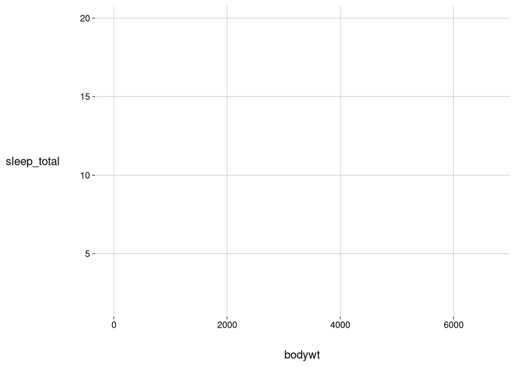

```r
sono %>%
  ggplot(aes(x = bodywt, y = sleep_total))
```

O que houve? Cadê os pontos?

O problema foi que só especificamos o mapeamento estético. Faltou a geometria.

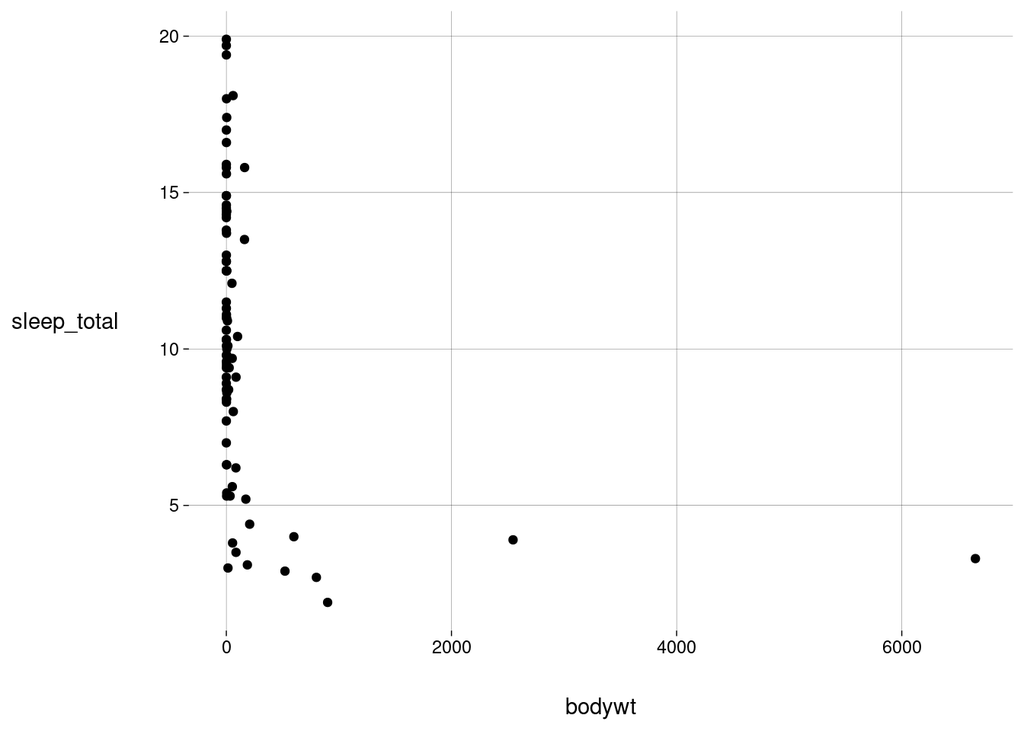

```r
sono %>%
  ggplot(aes(x = bodywt, y = sleep_total)) +
  geom_point()
```

Que horror.

A única coisa que percebemos aqui é que os mamíferos muito pesados dormem menos de 5 horas por noite.

Estes animais muito pesados estão estragando a escala do eixo $x$.

Que animais são estes?

```r
sono %>%
  filter(bodywt > 250) %>%
  select(name, bodywt) %>%
  arrange(bodywt)
```

| name | bodywt |
| --- | --- |
| Horse | 521,000 |
| Cow | 600,000 |
| Pilot whale | 800,000 |
| Giraffe | 899,995 |
| Asian elephant | 2547,000 |
| African elephant | 6654,000 |

Além disso, há muitos pontos sobrepostos. Em bom português, *overplotting*.

Existem diversas maneiras de lidar com isso.

A primeira delas é alterando a opacidade dos pontos:

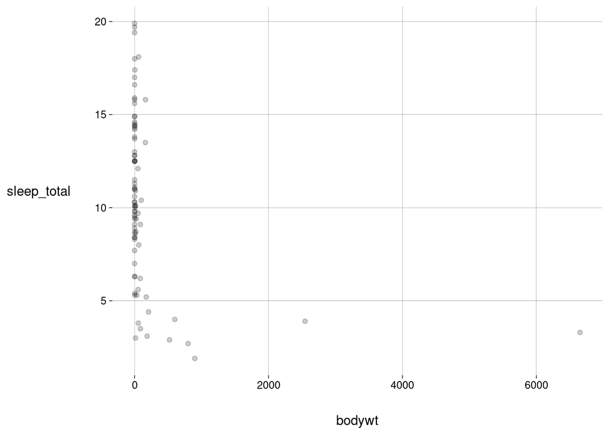

```r
sono %>%
  ggplot(aes(x = bodywt, y = sleep_total)) +
    geom_point(alpha = 0.2)
```

Outra maneira é usar `geom_jitter` em vez de `geom_point`:

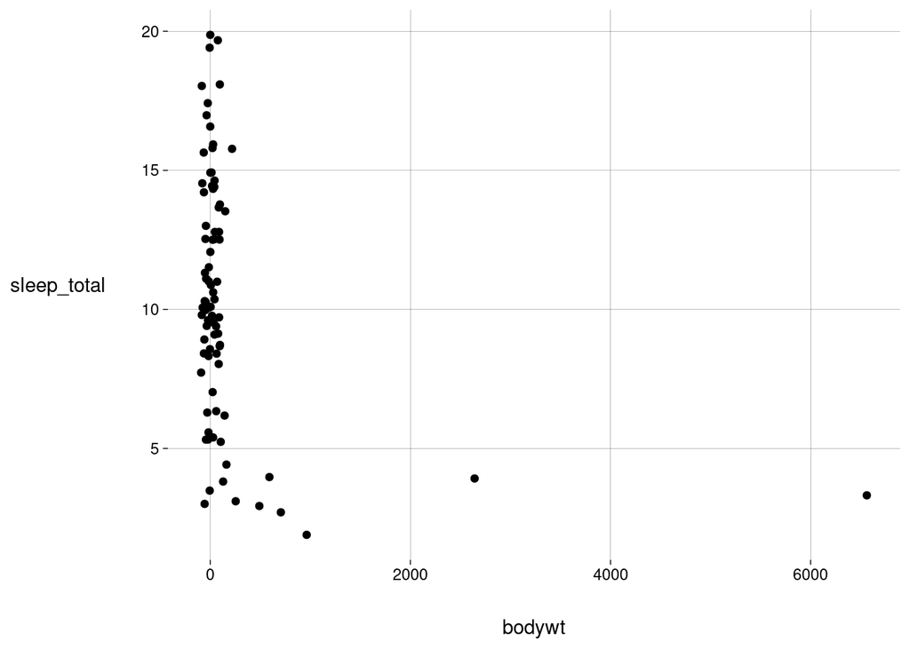

```r
sono %>%
  ggplot(aes(x = bodywt, y = sleep_total)) +
    geom_jitter(width = 100)
```

Vamos mudar a escala do gráfico para nos concentrarmos nos animais menos pesados:

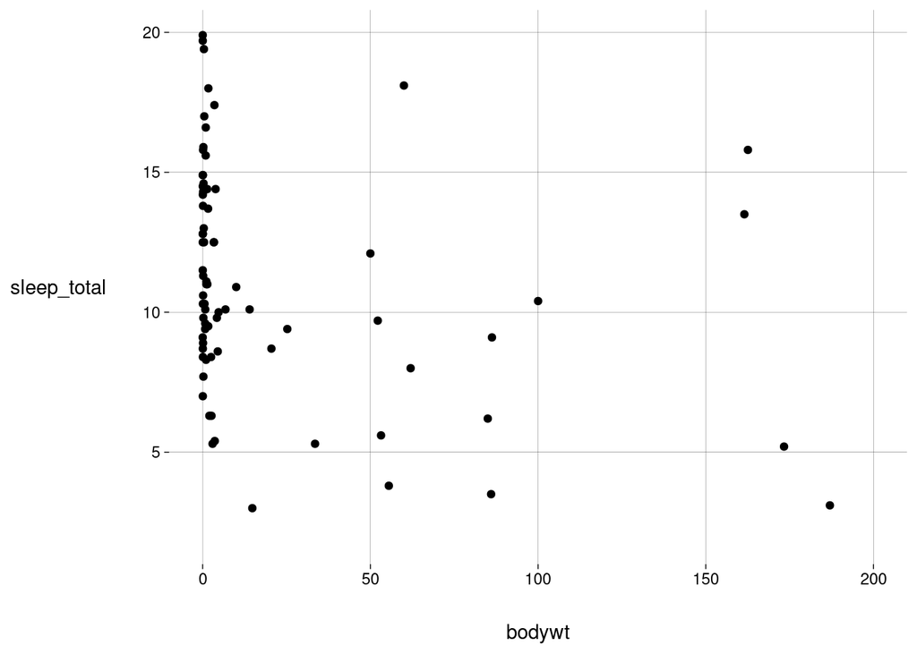

```r
sono %>%
  ggplot(aes(x = bodywt, y = sleep_total)) +
    geom_point() +
    scale_x_continuous(limits = c(0, 200))
```

Nesta escala, a relação entre horas de sono e peso não é mais tão regular.

## 3.2 Horas de sono e peso corporal para animais pequenos

Vamos restringir o gráfico a animais com no máximo 5kg.

```r
limite <- 5
```

Em vez de mudar a escala do gráfico, vamos filtrar as linhas do *data frame*:

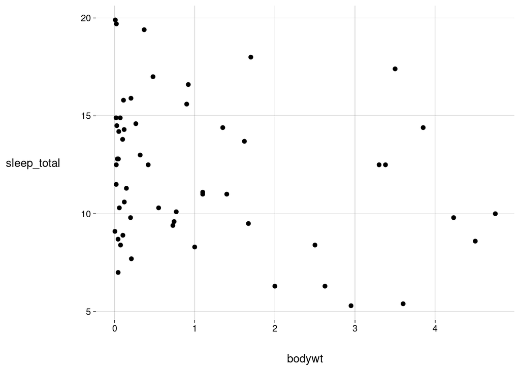

```r
sono %>%
  filter(bodywt < limite) %>%
  ggplot(aes(x = bodywt, y = sleep_total)) +
    geom_point()
```

## 3.3 Incluindo a dieta

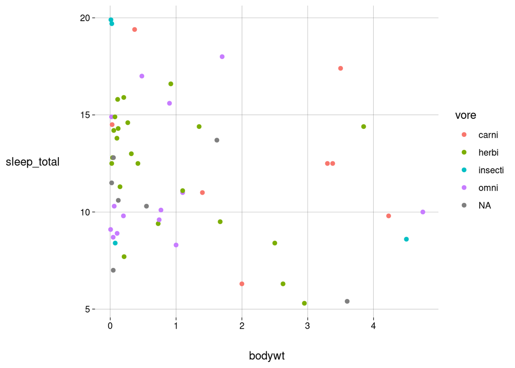

```r
sono %>%
  filter(bodywt < limite) %>%
  ggplot(aes(x = bodywt, y = sleep_total, color = vore)) +
    geom_point()
```

## 3.4 A estética pode ser especificada na `geom`

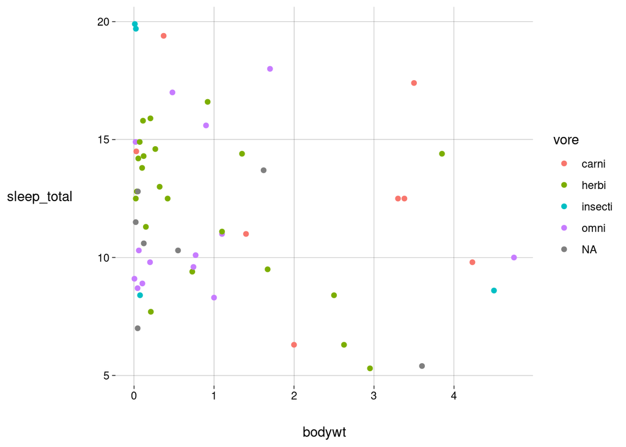

```r
sono %>%
  filter(bodywt < limite) %>%
  ggplot() +
    geom_point(aes(x = bodywt, y = sleep_total, color = vore))
```

## 3.5 Estética fixa ou dependendo de variável?

Compare o último chunk acima com:

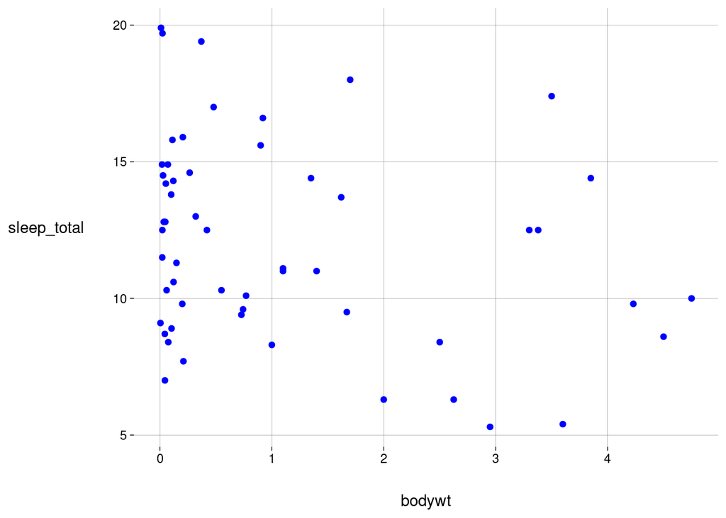

```r
sono %>%
  filter(bodywt < limite) %>%
  ggplot() +
    geom_point(aes(x = bodywt, y = sleep_total), color = 'blue')
```

Um erro comum:

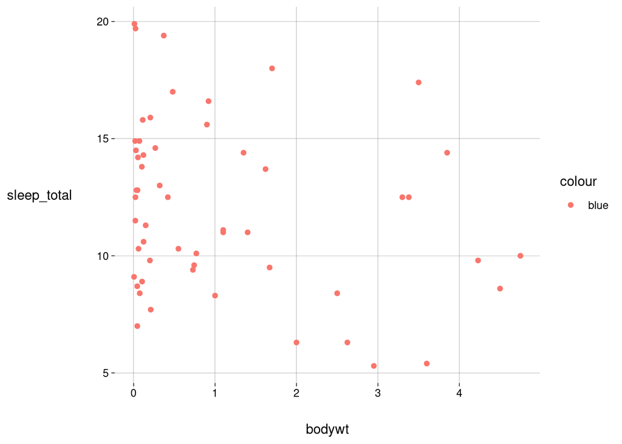

```r
sono %>%
  filter(bodywt < limite) %>%
  ggplot() +
    geom_point(aes(x = bodywt, y = sleep_total, color = 'blue'))
```

## 3.6 Uma correlação mais clara

Peso cerebral versus peso corporal:

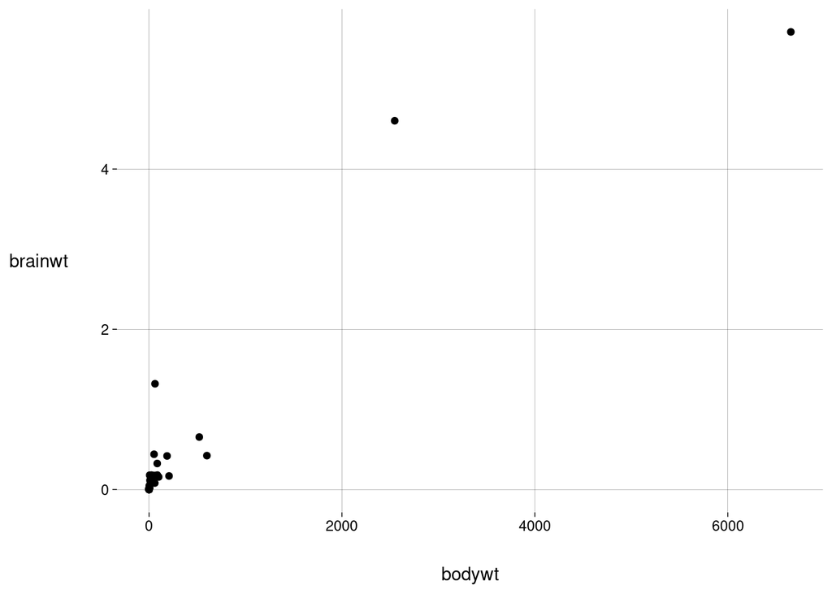

```r
sono %>%
  ggplot() +
    geom_point(aes(x = bodywt, y = brainwt))
```

Vamos restringir aos animais mais leves e mudar a opacidade:

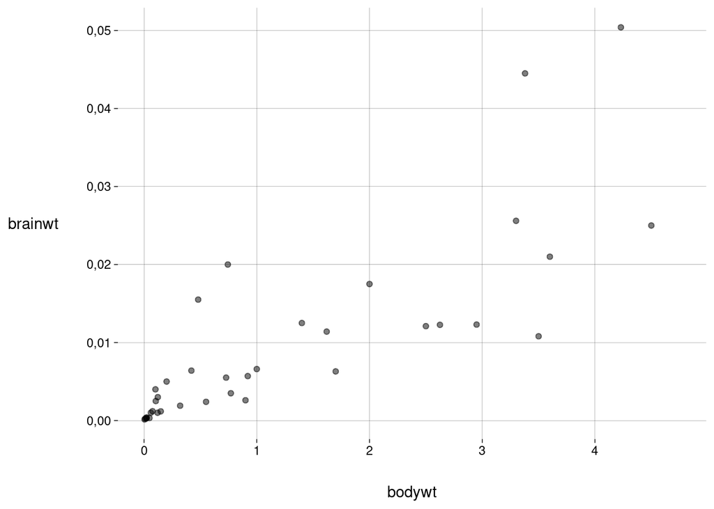

```r
sono %>%
  filter(bodywt < limite) %>%
  ggplot() +
    geom_point(aes(x = bodywt, y = brainwt), alpha = .5)
```

Vamos incluir horas de sono e dieta:

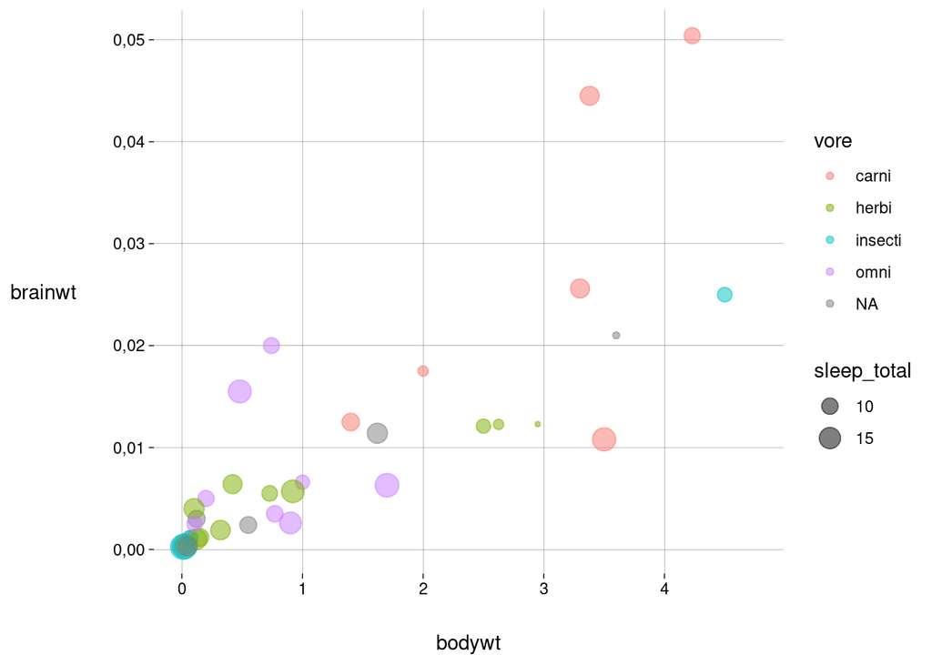

```r
sono %>%
  filter(bodywt < limite) %>%
  ggplot() +
    geom_point(
      aes(
        x = bodywt,
        y = brainwt,
        size = sleep_total,
        color = vore
      ),
      alpha = .5
    )
```

Mudar a escala dos tamanhos e incluir rótulos:

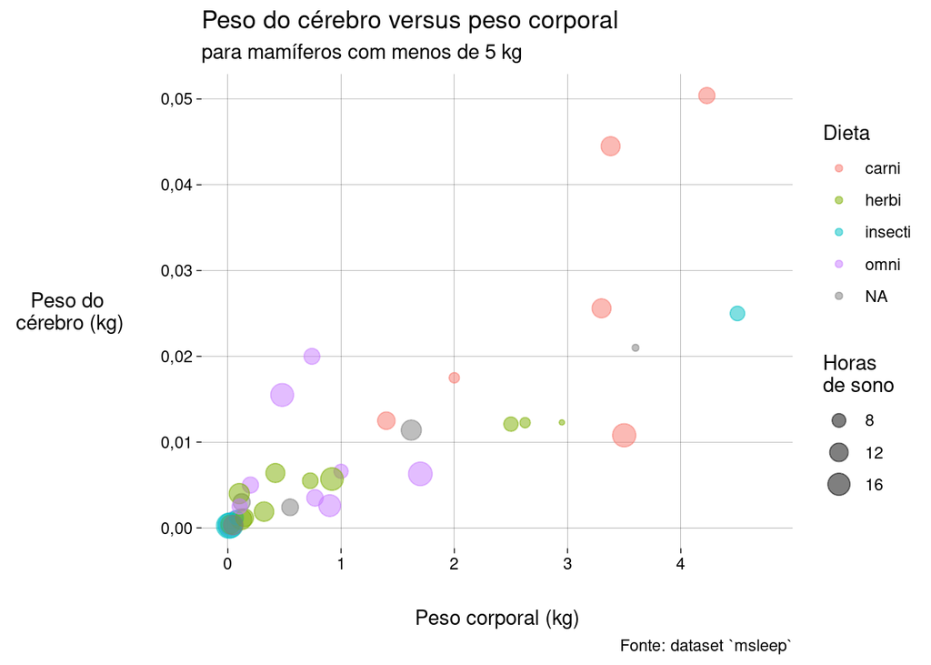

```r
sono %>%
  filter(bodywt < limite) %>%
  ggplot() +
    geom_point(
      aes(
        x = bodywt,
        y = brainwt,
        size = sleep_total,
        color = vore
      ),
      alpha = .5
    ) +
    scale_size(
      breaks = seq(0, 24, 4)
    ) +
    labs(
      title = 'Peso do cérebro versus peso corporal',
      subtitle = paste0('para mamíferos com menos de ', limite, ' kg'),
      caption = 'Fonte: dataset `msleep`',
      x = 'Peso corporal (kg)',
      y = 'Peso do\n cérebro (kg)',
      color = 'Dieta',
      size = 'Horas\nde sono'
    )
```

# 4 Histogramas e cia.

A idéia agora é agrupar indivíduos em classes, dependendo do valor de uma variável numérica.

Vamos nos concentrar nas horas de sono.

## 4.1 Distribuições de frequência

Em R base, é fácil fazer os agrupamentos:

```r
sono$sleep_total
```

```
##  [1] 12,1 17,0 14,4 14,9  4,0 14,4  8,7  7,0 10,1  3,0  5,3  9,4 10,0 12,5 10,3
## [16]  8,3  9,1 17,4  5,3 18,0  3,9 19,7  2,9  3,1 10,1 10,9 14,9 12,5  9,8  1,9
## [31]  2,7  6,2  6,3  8,0  9,5  3,3 19,4 10,1 14,2 14,3 12,8 12,5 19,9 14,6 11,0
## [46]  7,7 14,5  8,4  3,8  9,7 15,8 10,4 13,5  9,4 10,3 11,0 11,5 13,7  3,5  5,6
## [61] 11,1 18,1  5,4 13,0  8,7  9,6  8,4 11,3 10,6 16,6 13,8 15,9 12,8  9,1  8,6
## [76] 15,8  4,4 15,6  8,9  5,2  6,3 12,5  9,8
```

```r
sono$sleep_total %>% range()
```

```
## [1]  1,9 19,9
```

```r
sono$sleep_total %>%
  cut(breaks = seq(0, 20, 2), right = FALSE)
```

```
##  [1] [12,14) [16,18) [14,16) [14,16) [4,6)   [14,16) [8,10)  [6,8)   [10,12)
## [10] [2,4)   [4,6)   [8,10)  [10,12) [12,14) [10,12) [8,10)  [8,10)  [16,18)
## [19] [4,6)   [18,20) [2,4)   [18,20) [2,4)   [2,4)   [10,12) [10,12) [14,16)
## [28] [12,14) [8,10)  [0,2)   [2,4)   [6,8)   [6,8)   [8,10)  [8,10)  [2,4)
## [37] [18,20) [10,12) [14,16) [14,16) [12,14) [12,14) [18,20) [14,16) [10,12)
## [46] [6,8)   [14,16) [8,10)  [2,4)   [8,10)  [14,16) [10,12) [12,14) [8,10)
## [55] [10,12) [10,12) [10,12) [12,14) [2,4)   [4,6)   [10,12) [18,20) [4,6)
## [64] [12,14) [8,10)  [8,10)  [8,10)  [10,12) [10,12) [16,18) [12,14) [14,16)
## [73] [12,14) [8,10)  [8,10)  [14,16) [4,6)   [14,16) [8,10)  [4,6)   [6,8)
## [82] [12,14) [8,10)
## 10 Levels: [0,2) [2,4) [4,6) [6,8) [8,10) [10,12) [12,14) [14,16) ... [18,20)
```

```r
sono$sleep_total %>%
  cut(breaks = seq(0, 20, 2), right = FALSE) %>%
  table(dnn = 'Horas de sono') %>%
  as.data.frame()
```

| Horas.de.sono | Freq |
| --- | --- |
| [0,2) | 1 |
| [2,4) | 8 |
| [4,6) | 7 |
| [6,8) | 5 |
| [8,10) | 17 |
| [10,12) | 14 |
| [12,14) | 11 |
| [14,16) | 12 |
| [16,18) | 3 |
| [18,20) | 5 |

## 4.2 Histogramas

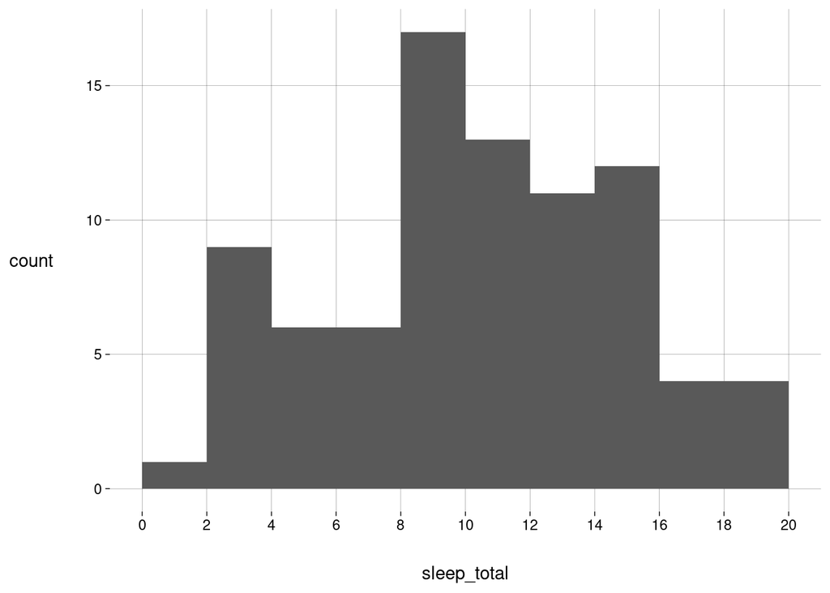

```r
sono %>%
  ggplot(aes(x = sleep_total)) +
    geom_histogram(breaks = seq(0, 20, 2)) +
    scale_x_continuous(breaks = seq(0, 20, 2))
```

## 4.3 Polígonos de frequência

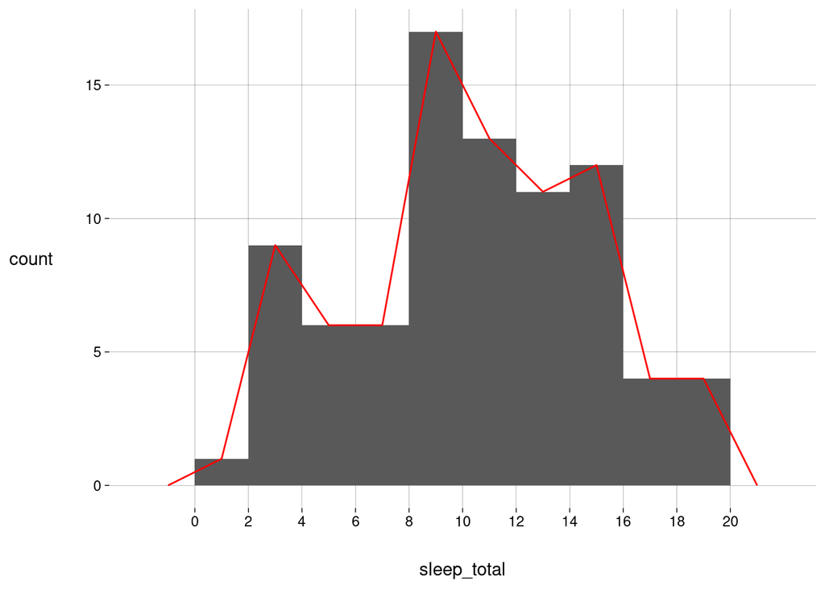

```r
sono %>%
  ggplot(aes(x = sleep_total)) +
    geom_histogram(breaks = seq(0, 20, 2)) +
    geom_freqpoly(breaks = seq(0, 20, 2), color = 'red') +
    scale_x_continuous(breaks = seq(0, 20, 2))
```

# 5 Ogivas (frequência acumulada)

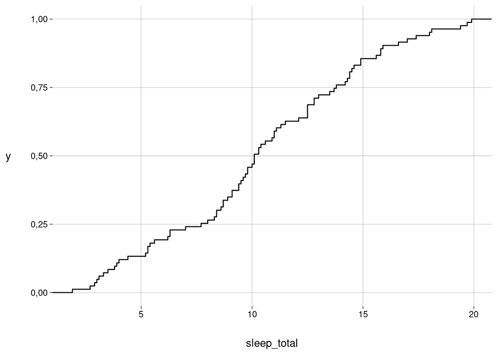

```r
sono %>%
  ggplot(aes(x = sleep_total)) +
  geom_step(stat = 'ecdf')
```

# 6 Ramos e folhas

```r
sono$sleep_total %>%
  stem()
```

```
##
##   The decimal point is at the |
##
##    0 | 9
##    2 | 79013589
##    4 | 0423346
##    6 | 23307
##    8 | 03446779114456788
##   10 | 01113346900135
##   12 | 15555880578
##   14 | 234456996889
##   16 | 604
##   18 | 01479
```

# 7 Exercícios

1. Construa um histograma da variável `brainwt`. Escolha o número de classes que você achar melhor. O que acontece com os valores `NA`?
2. Construa um *scatter plot* de horas de sono versus peso do cérebro. Você percebe alguma correlação entre estas variáveis?